# Final_presentation_OwnDataset

LOGISTIC REGRESSION

```r
str(b_data)
```

```
## spc_tbl_ [197 × 22] (S3: spec_tbl_df/tbl_df/tbl/data.frame)
##  $ rank                : num [1:197] 1 2 3 4 5 6 7 8 9 10 ...
##  $ age                 : num [1:197] 74 51 59 78 92 67 81 83 65 67 ...
##  $ finalWorth          : num [1:197] 211000 180000 114000 107000 106000 104000 94500 93000 83400 80700 ...
##  $ birthYear           : num [1:197] 1949 1971 1964 1944 1930 ...
##  $ birthMonth          : num [1:197] 3 6 1 8 8 10 2 1 4 3 ...
##  $ birthDay            : num [1:197] 5 28 12 17 30 28 14 28 19 24 ...
##  $ category            : chr [1:197] "Fashion & Retail" "Automotive" "Technology" "Technology" ...
##  $ personName          : chr [1:197] "Bernard Arnault & family" "Elon Musk" "Jeff Bezos" "Larry Ellison" ...
##  $ country             : chr [1:197] "France" "United States" "United States" "United States" ...
##  $ city                : chr [1:197] "Paris" "Austin" "Medina" "Lanai" ...
##  $ source              : chr [1:197] "LVMH" "Tesla, SpaceX" "Amazon" "Oracle" ...
##  $ industries          : chr [1:197] "Fashion & Retail" "Automotive" "Technology" "Technology" ...
##  $ countryOfCitizenship: chr [1:197] "France" "United States" "United States" "United States" ...
##  $ organization        : chr [1:197] "LVMH Moët Hennessy Louis Vuitton" "Tesla" "Amazon" "Oracle" ...
##  $ selfMade            : logi [1:197] FALSE TRUE TRUE TRUE TRUE TRUE ...
##  $ gender              : chr [1:197] "M" "M" "M" "M" ...
##  $ birthDate           : chr [1:197] "3/5/49 0:00" "6/28/71 0:00" "1/12/64 0:00" "8/17/44 0:00" ...
##  $ state               : chr [1:197] NA "Texas" "Washington" "Hawaii" ...
##  $ residenceStateRegion: chr [1:197] NA "South" "West" "West" ...
##  $ cpi_country         : num [1:197] 110 117 117 117 117 ...
##  $ cpi_change_country  : num [1:197] 1.1 7.5 7.5 7.5 7.5 7.5 7.5 3.6 7.7 7.5 ...
##  $ gdp_country         : chr [1:197] "$2,715,518,274,227.00" "$21,427,700,000,000.00" "$21,427,700,000,000.00" "$21,427,700,000,000.00" ...
##  - attr(*, "spec")=
##   .. cols(
##   ..   rank = col_double(),
##   ..   age = col_double(),
##   ..   finalWorth = col_double(),
##   ..   birthYear = col_double(),
##   ..   birthMonth = col_double(),
##   ..   birthDay = col_double(),
##   ..   category = col_character(),
##   ..   personName = col_character(),
##   ..   country = col_character(),
##   ..   city = col_character(),
##   ..   source = col_character(),
##   ..   industries = col_character(),
##   ..   countryOfCitizenship = col_character(),
##   ..   organization = col_character(),
##   ..   selfMade = col_logical(),
##   ..   gender = col_character(),
##   ..   birthDate = col_character(),
##   ..   state = col_character(),
##   ..   residenceStateRegion = col_character(),
##   ..   cpi_country = col_double(),
##   ..   cpi_change_country = col_double(),
##   ..   gdp_country = col_character()
##   .. )
##  - attr(*, "problems")=<externalptr>
```

```r
colnames(b_data)
```

```
##  [1] "rank"                 "age"                  "finalWorth"
##  [4] "birthYear"            "birthMonth"           "birthDay"
##  [7] "category"             "personName"           "country"
## [10] "city"                 "source"               "industries"
## [13] "countryOfCitizenship" "organization"         "selfMade"
## [16] "gender"               "birthDate"            "state"
## [19] "residenceStateRegion" "cpi_country"          "cpi_change_country"
## [22] "gdp_country"
```

```r
# Factorize categorical
b_data$gender <- as.factor(b_data$gender)
b_data$selfMade <- as.factor(b_data$selfMade)


# Split the data into training and testing sets
set.seed(123) # for reproducibility
train_index <- sample(1:nrow(b_data), 0.7 * nrow(b_data))
train_data <- b_data[train_index, ]
test_data <- b_data[-train_index, ]

# Build the logistic regression model
model <- glm(gender ~ age + finalWorth + selfMade, data = train_data, family = binomial)

# Summary of the model
summary(model)
```

```
##
## Call:
## glm(formula = gender ~ age + finalWorth + selfMade, family = binomial,
##     data = train_data)
##
## Coefficients:
##                Estimate Std. Error z value Pr(>|z|)
## (Intercept)  -8.584e-01  1.564e+00  -0.549  0.58304
## age           1.604e-02  2.179e-02   0.736  0.46172
## finalWorth    1.554e-05  1.745e-05   0.891  0.37319
## selfMadeTRUE  3.947e+00  1.058e+00   3.732  0.00019 ***
## ---
## Signif. codes:  0 '***' 0.001 '**' 0.01 '*' 0.05 '.' 0.1 ' ' 1
##
## (Dispersion parameter for binomial family taken to be 1)
##
##     Null deviance: 102.748  on 136  degrees of freedom
## Residual deviance:  68.587  on 133  degrees of freedom
## AIC: 76.587
##
## Number of Fisher Scoring iterations: 7
```

```r
# Assess model performance on the test set
predicted <- predict(model, test_data, type = "response")
predicted
```

```
##         1         2         3         4         5         6         7         8
## 0.9987752 0.9970008 0.9955802 0.8174715 0.9947062 0.7351360 0.7759618 0.7837742
##         9        10        11        12        13        14        15        16
## 0.9938861 0.7526104 0.9944408 0.9920328 0.9859016 0.9937610 0.9924039 0.9912745
##        17        18        19        20        21        22        23        24
## 0.9865881 0.6039854 0.6969711 0.6864861 0.6967484 0.6882632 0.9890000 0.9859640
##        25        26        27        28        29        30        31        32
## 0.9896658 0.9896072 0.6347988 0.6448132 0.9880486 0.9855043 0.9828950 0.9855557
##        33        34        35        36        37        38        39        40
## 0.6691697 0.9902360 0.9860764 0.9921118 0.6067832 0.9892325 0.9829640 0.6528179
##        41        42        43        44        45        46        47        48
## 0.9882720 0.9882417 0.9898893 0.9797014 0.9883195 0.9853993 0.9884679 0.9875169
##        49        50        51        52        53        54        55        56
## 0.9833318 0.9902553 0.9847215 0.9815385 0.9896692 0.9862589 0.9882714 0.9802492
##        57        58        59        60
## 0.5573467 0.5279474 0.9859324 0.5708292
```

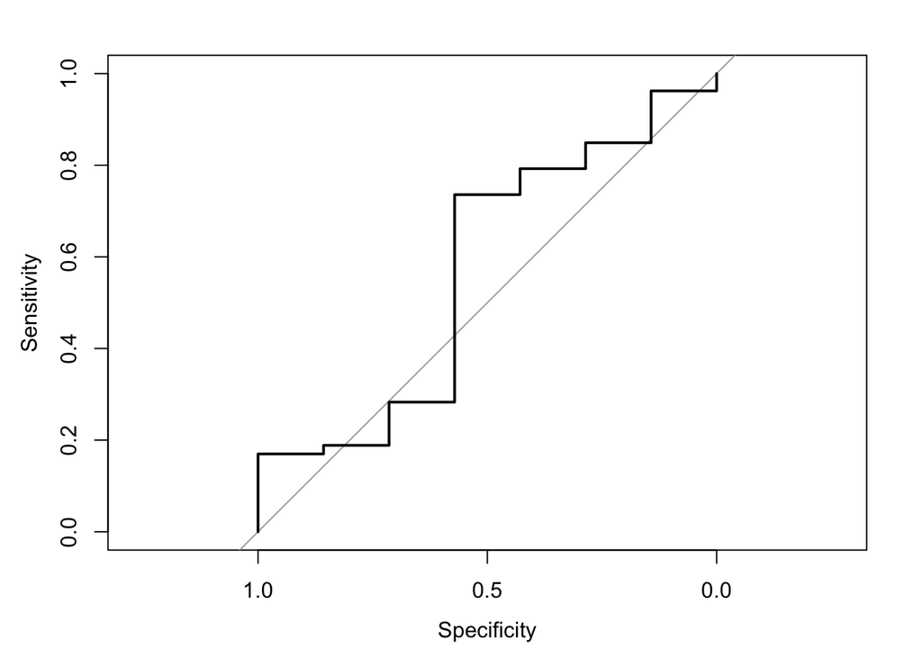

```r
# Create a dataframe containing predicted values and observed values (gender)
prediction_data <- data.frame(predicted = predicted, observed = test_data$gender)
# Re-run prediction

# ROC curve
roc_obj <- roc(prediction_data$observed, prediction_data$predicted)
plot(roc_obj)
```

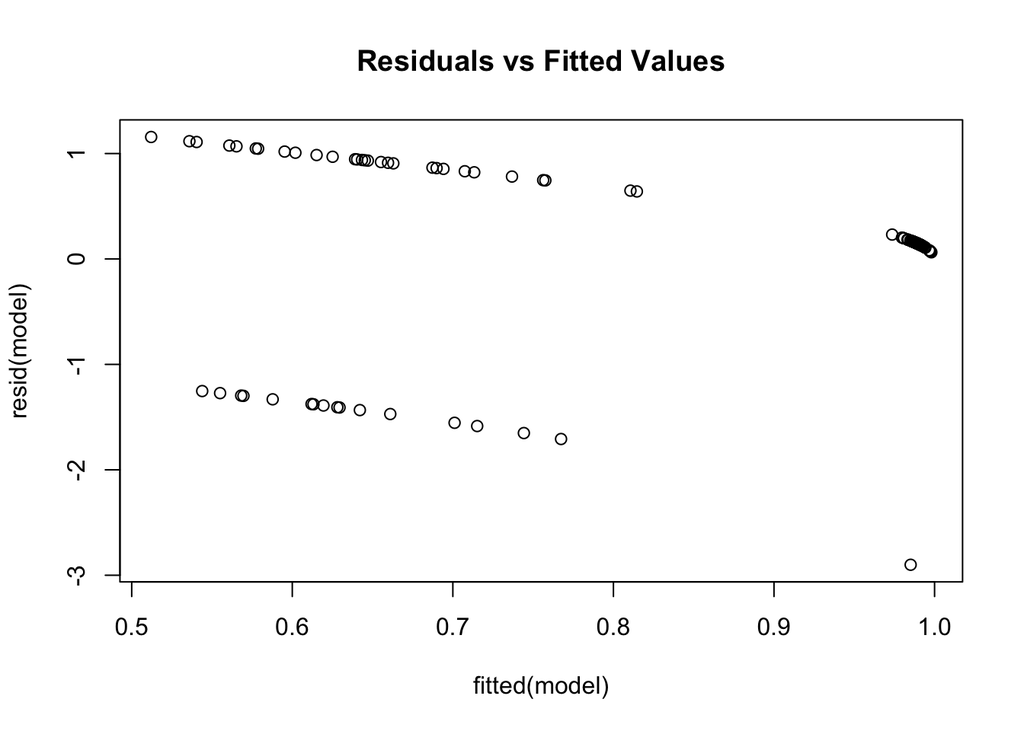

```r
predictions <- predict(model, newdata = test_data, type = "response")

# Convert predicted probabilities to binary predictions
binary_predictions <- ifelse(predictions > 0.1, 1, 0)


# Residual analysis
# Plot residuals vs fitted values
plot(resid(model) ~ fitted(model), main = "Residuals vs Fitted Values")
```

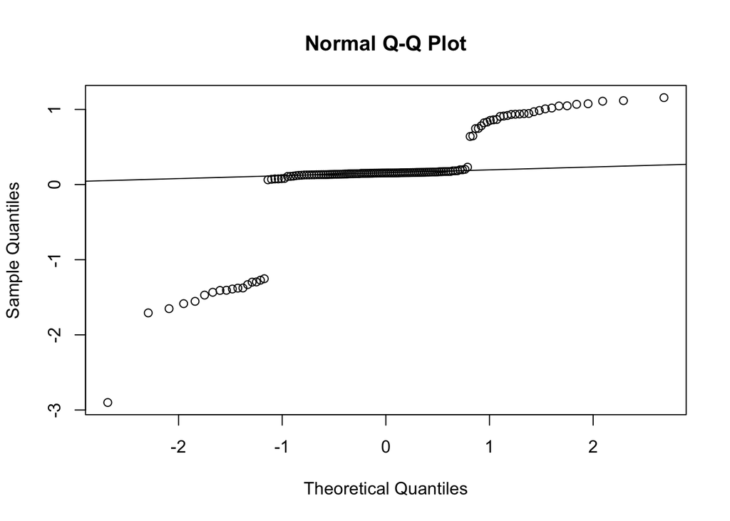

```r
# Plot Q-Q plot of residuals
qqnorm(resid(model))
qqline(resid(model))
```

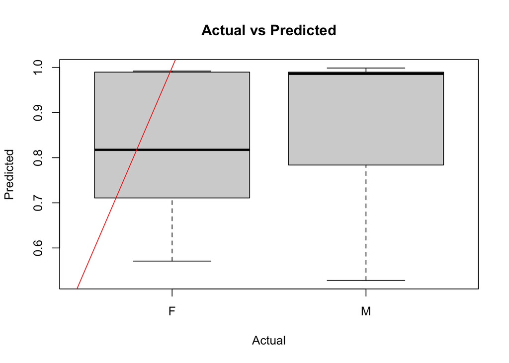

```r
# Plot predictions
plot(test_data$gender, predictions, main = "Actual vs Predicted", xlab = "Actual", ylab = "Predicted")
abline(0, 1, col = "red")
```

```r
#binary_predictions <- as.factor(binary_predictions)
accuracy <- mean(binary_predictions == test_data$gender)
accuracy
```

```
## [1] 0
```

#Center line: The horizontal line in the middle of the box represents the median predicted value. It divides the data into two halves, with half the predictions having values higher than the median and the other half having values lower. #Box: The box represents the interquartile range (IQR), which encompasses the middle 50% of the predicted values. The bottom edge of the box corresponds to the first quartile (Q1) and the top edge to the third quartile (Q3).